# Loan Classification Modeling

Zach

2023-11-14

##Objective We have a dataset of a group of customers from Universal Bank. Universal Bank wants to find prospective customers to send out loan offers to. They want to be efficient with who they send the offer out to for a few reasons. 1. Universal Bank does a lot of digital offers and advertising, they do their best to avoid spam emails to where offers such as this get lost in an endless stream of communication from them. 2. Universal Bank wants this offer to feel exclusive, they feel making this offer available to only a select few will improve response rate, however they do not want to miss out on potential customers. Finally, Universal Bank does not want to not only avoid spam communication, they just want to be financially efficient with their resources. With the given Data Universal Bank wants a way to analyze current customers without loans and give a list of potential customers most likely to be interested in a loan.

##Plan With the given data set I will train a few classification models to predict which customers have loans. I will then test and analyze performance of the models. The best model will be selected for Universal Bank to take their whole data set of customers without loans to efficiently, find the most likely customers to accept this loan offer.

```r
rm(list = ls())
suppressWarnings(library(tidyverse))
library(caret)
library(performanceEstimation)
library(PRROC)
library(rpart)
```

```r
# Read in data and remove unneccessary features
bank = read_csv("UniversalBank.csv") %>%
  select(-ID, -`ZIP Code`, -Experience) %>%
  rename(Loan = `Personal Loan`,
         Securities = `Securities Account`,
         CD = `CD Account`) %>%
  mutate(Loan = factor(Loan)) %>%
  mutate_at(vars(Education), .funs = factor)
```

Below we can check for missing data.

```r
head(bank)
```

```
## # A tibble: 6 x 11
##     Age Income Family CCAvg Education Mortgage Loan  Securities    CD Online
##   <dbl>  <dbl>  <dbl> <dbl> <fct>        <dbl> <fct>      <dbl> <dbl>  <dbl>
## 1    25     49      4   1.6 1                0 0              1     0      0
## 2    45     34      3   1.5 1                0 0              1     0      0
## 3    39     11      1   1   1                0 0              0     0      0
## 4    35    100      1   2.7 2                0 0              0     0      0
## 5    35     45      4   1   2                0 0              0     0      0
## 6    37     29      4   0.4 2              155 0              0     0      1
## # i 1 more variable: CreditCard <dbl>
```

```r
# MISSING DATA
# =============
# Calculate percent of missing values for features
missing_df =  as.numeric(purrr::map(bank, ~mean(is.na(.))))*100
# Assign values to data frame for easy viewing
df = data.frame(PercentMissing = missing_df,
                row.names = names(bank)) %>%
  arrange(desc(PercentMissing))

print(df)
```

```
##            PercentMissing
## Age                     0
## Income                  0
## Family                  0
## CCAvg                   0
## Education               0
## Mortgage                0
## Loan                    0
## Securities              0
## CD                      0
## Online                  0
## CreditCard              0
```

Fortunately, we don’t have any missing values.

## Partition Data

```r
# Partition the Data
set.seed(453)
idx = createDataPartition(bank$Loan, p = 0.7, list = FALSE)
train = bank[idx, ]
test = bank[-idx, ]
rm(idx)
```

#### Address Class Imbalance

```r
# Address class imbalance
table(train$Loan)
```

```
##
##    0    1
## 3164  336
```

```r
balanced_train = smote(Loan ~ .,
              data = train,
              perc.over = 7,
              perc.under = 1.3)
table(balanced_train$Loan)
```

```
##
##    0    1
## 3057 2688
```

## Best Tuned Decision Tree

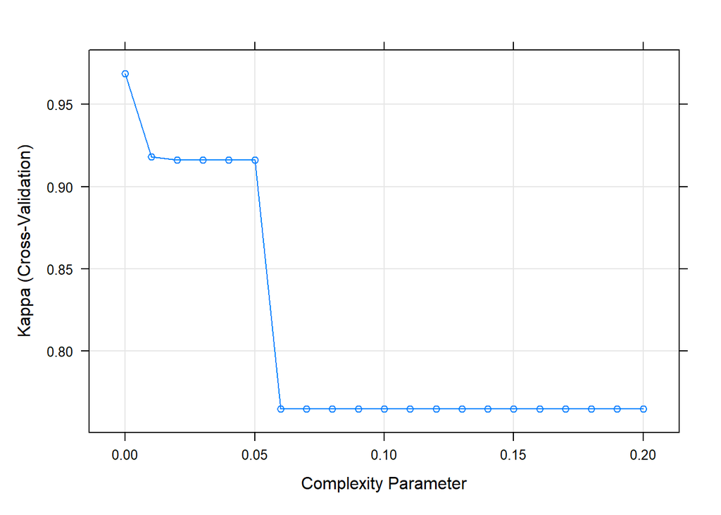

```r
# training and evaluation process
ctrl = caret::trainControl(method = "cv", number = 5)
set.seed(345)
tree = train(Loan ~ .,
             data = balanced_train,
             method = "rpart",
             metric = "Kappa",
             trControl = ctrl,
             tuneGrid = expand.grid(cp = seq(0.0, 0.2, 0.01)),
             control = rpart.control(minsplit = 1, minbucket = 1, maxdepth = 8)
             )

plot(tree)
```

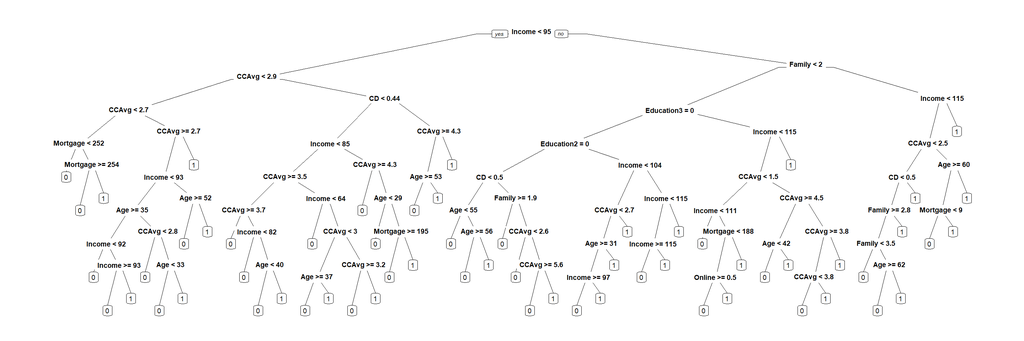

```r
library(rpart.plot)
prp(tree$finalModel)
```

## Best Tuned Random Forest

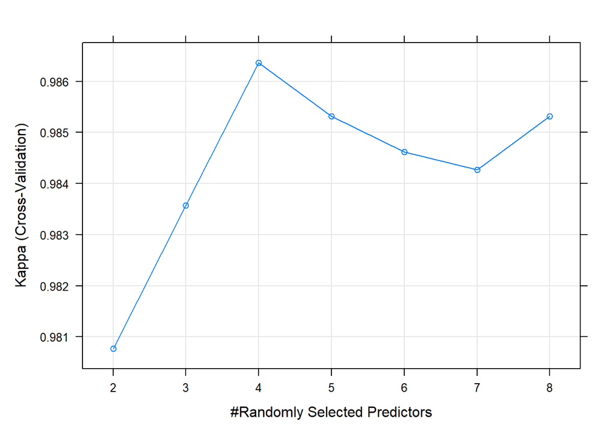

```r
set.seed(345)
forest = train(Loan ~ .,
                        data = balanced_train,
                        method = "rf",
                        metric = "Kappa",
                        trControl = ctrl,
                        ntree = 50,
                        tuneGrid = expand.grid(.mtry = seq(2,8,1))
                      )

plot(forest)
```

We will use the model with 4 randomly selected predictors.

## Best Tuned Boosting (Adaboost / Gradient Boosting)

The below chunk was preformed previously and took a long time. It will be saved and loaded in

```r
#boost_grid = expand.grid(
#  maxdepth = c(4,5,6,7,8),
# iter = c(100,150,200),
#nu = 0.5)

#boost_ctrl = trainControl(method = "cv",
#                          number = 5,
#                         allowParallel = TRUE)
#set.seed(345)
#boosted_trees = train(Loan ~ .,
#                     data = balanced_train,
#                      trControl = boost_ctrl
#                      tuneGrid = boost_grid,
#                     method = "ada",
#                      metric = "Kappa")
```

```r
#saveRDS(boosted_trees, file = 'boosted_trees_rds.rds')
```

```r
boosted_trees1<-readRDS( 'boosted_trees_rds.rds')
```

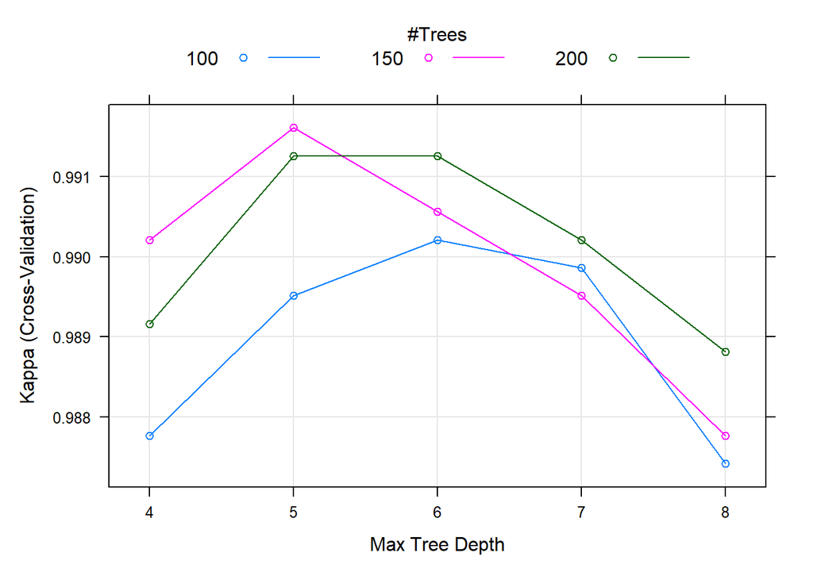

```r
plot(boosted_trees1)
```

## Compare Precision and Sensitivity

```r
# Convert Y in test data to numeric 0, 1.
test = mutate(test, Loan = as.numeric(ifelse(Loan=="1", 1, 0)))

# Create explainers
tree_explain = DALEX::explain(tree,
                              data = test,
                              y = test$Loan,
                              type = "classification",
                              label = "Decision Tree")
```

```
## Preparation of a new explainer is initiated
##   -> model label       :  Decision Tree
##   -> data              :  1500  rows  11  cols
##   -> data              :  tibble converted into a data.frame
##   -> target variable   :  1500  values
##   -> predict function  :  yhat.train  will be used (  default  )
##   -> predicted values  :  No value for predict function target column. (  default  )
##   -> model_info        :  package caret , ver. 6.0.94 , task classification (  default  )
##   -> model_info        :  type set to  classification
##   -> predicted values  :  numerical, min =  0 , mean =  0.1111292 , max =  1
##   -> residual function :  difference between y and yhat (  default  )
##   -> residuals         :  numerical, min =  -1 , mean =  -0.01512918 , max =  1
##   A new explainer has been created!
```

```r
forest_explain = DALEX::explain(forest,
                                data = test,
                                y = test$Loan,
                                type = "classification",
                                label = "Random Forest")
```

```
## Preparation of a new explainer is initiated
##   -> model label       :  Random Forest
##   -> data              :  1500  rows  11  cols
##   -> data              :  tibble converted into a data.frame
##   -> target variable   :  1500  values
##   -> predict function  :  yhat.train  will be used (  default  )
##   -> predicted values  :  No value for predict function target column. (  default  )
##   -> model_info        :  package caret , ver. 6.0.94 , task classification (  default  )
##   -> model_info        :  type set to  classification
##   -> predicted values  :  numerical, min =  0 , mean =  0.1162933 , max =  1
##   -> residual function :  difference between y and yhat (  default  )
##   -> residuals         :  numerical, min =  -0.94 , mean =  -0.02029333 , max =  0.94
##   A new explainer has been created!
```

```r
adaboost_explain = DALEX::explain(boosted_trees1,
                                  data = test,
                                  y = test$Loan,
                                  type = "classification",
                                  label = "AdaBoost")
```

```
## Preparation of a new explainer is initiated
##   -> model label       :  AdaBoost
##   -> data              :  1500  rows  11  cols
##   -> data              :  tibble converted into a data.frame
##   -> target variable   :  1500  values
##   -> predict function  :  yhat.train  will be used (  default  )
##   -> predicted values  :  No value for predict function target column. (  default  )
##   -> model_info        :  package caret , ver. 6.0.94 , task classification (  default  )
##   -> model_info        :  type set to  classification
##   -> predicted values  :  numerical, min =  7.945019e-24 , mean =  0.1016185 , max =  1
##   -> residual function :  difference between y and yhat (  default  )
##   -> residuals         :  numerical, min =  -1 , mean =  -0.005618483 , max =  1
##   A new explainer has been created!
```

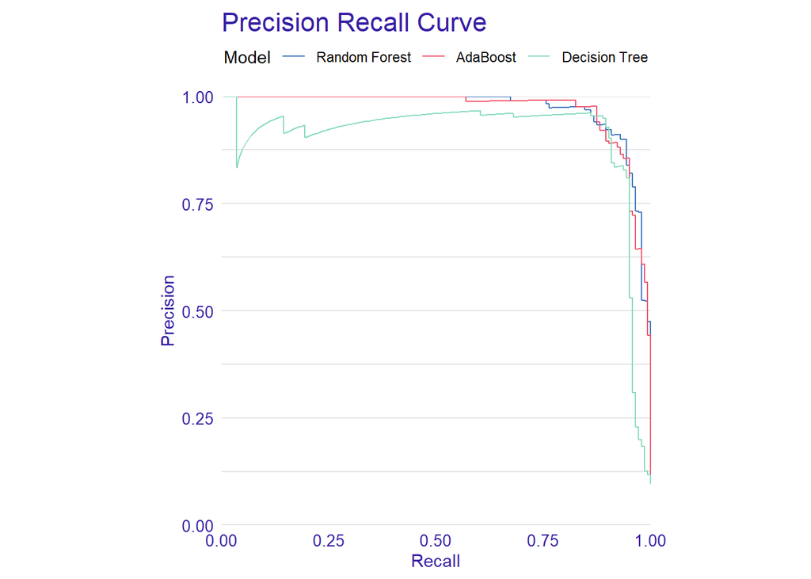

```r
# Model Performance
tree_perf = DALEX::model_performance(tree_explain)
forest_perf = DALEX::model_performance(forest_explain)
adaboost_perf = DALEX::model_performance(adaboost_explain)

# Plot the Precision Recall Curve
plot(tree_perf, forest_perf, adaboost_perf, geom = 'prc')
```

Random Forest and AdaBoost preform very similarly, but the decision tree model preforms slightly worst.

## ROC Plot and Comparing AUC

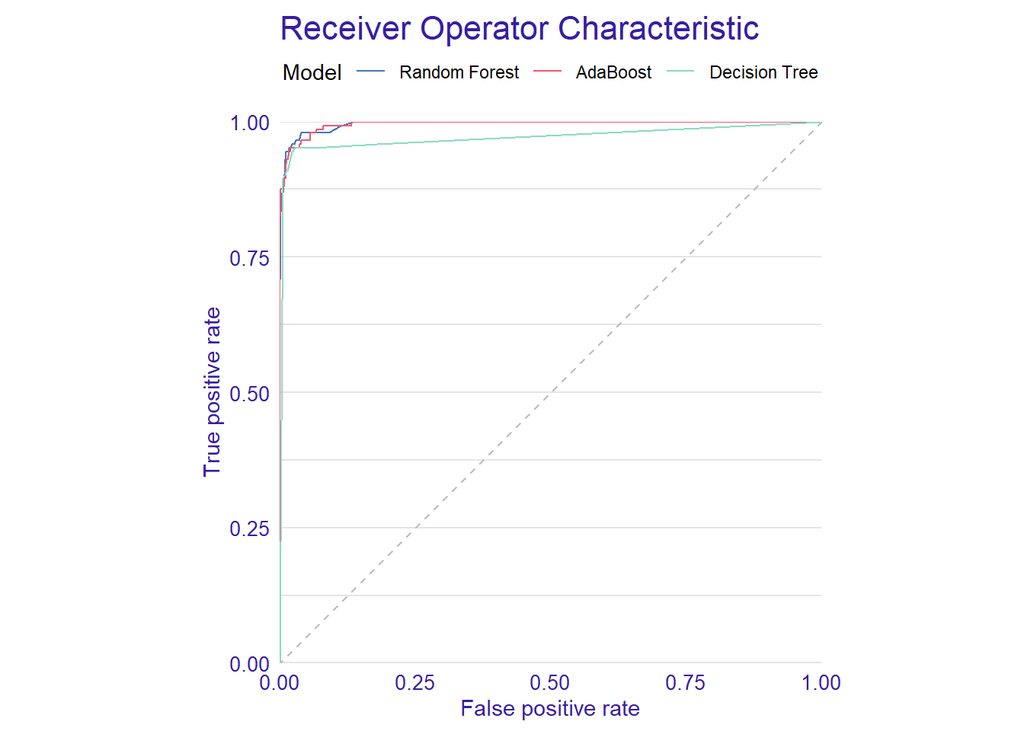

```r
# Plot the ROC
plot(tree_perf, forest_perf, adaboost_perf, geom = 'roc')
```

```r
# Compare the AUCs
matrix(c("Model",
         "Decision Tree",
         "Random Forest",
         "Adaboost",
         "AUC",
         round(tree_perf$measures$auc,3),
         round(forest_perf$measures$auc, 3),
         round(adaboost_perf$measures$auc, 3)),
       ncol = 2)
```

```
##      [,1]            [,2]
## [1,] "Model"         "AUC"
## [2,] "Decision Tree" "0.971"
## [3,] "Random Forest" "0.996"
## [4,] "Adaboost"      "0.996"
```

Random Forest and Adaboost have identical AUCs. Random Forrest took a lot less computational resources to produce the model so therefor the best model for this classification problem is determined to be the Random Forest.

Partitioning Data

In order to have correct and ethical models it is critical to partition data. If models were given partitioned data it would lead to over fitting. This is when the model fits the training data too well. The models effectiveness would be measured using data it has already seen. This is an issue because it gives a false illusion of confidence. This can lead to decisions being misadvised and incorrect evaluation of risks. Additionally, in some situations it could be ethical as well. If a model makes money based on performance and the measured performance is illegitimate that is knowingly lying to consumers.

Bagging and Ensemble

This type of modeling uses many small “weak learning” models all combined into one “strong learning” model. The largest benefit is we essentially have the efforts of many models being trained individually combining into one. This decreases the chances of issues from randomization because there are so many models. With so many different models their is less also of a chance of over fitting as well.